# Law_Diffusion

Annick Peter & Fabia Jenny

2023-12-22

## Introdcution

Harvard and Yale are widely recognized as some of the most prestigious universities in the world and their scholars are among the best known and most respected. However, as the 2023 fraud scandal involving university professor Francesca Gino shows, their reputation is not immune from all harm. Gino had allegedly fabricated the data in at least four of her studies - a news that has “sent shock waves through the behavioral science community”. [(Nesterak,2023)](https://behavioralscientist.org/harvard-professor-under-scrutiny-for-alleged-data-fraud/) The incidence has raised doubts about the reliability of Harwards research and contributed to a loss of trust among researchers in the said scientific community.

This blog post models how rumors of fraud might could impact perception of Harvard graduates in the legal field. In what way does gossip circulating in legal circles affect people’s trust in the advice from Harvard/Yale graduates, potentially diminishing the exchange of advice among lawyers in general?

# Data

We used three networks —law_advice, law_cowork, and law_friends—from the networkdata package. The data derived from a network study of the corporate law partnership in the law firm SG&R in 1988-1991 in New England [(Lazega, 2001)] (https://doi.org/10.1093/esr/jci012) includes attibutes such as seniority, formal status, office, gender and the law school of the firm’s 71 attorneys (partners and associates).

It is assumed that information on legal practices, law interpretation and ideal pleading strategies is diffused through the advice network. The law_cowork illustrates whether lawyers have worked together on cases, whereas law_friends maps the friendship among attorneys. General work-related but also private information is shared via those network ties.

Let’s have a look at them:

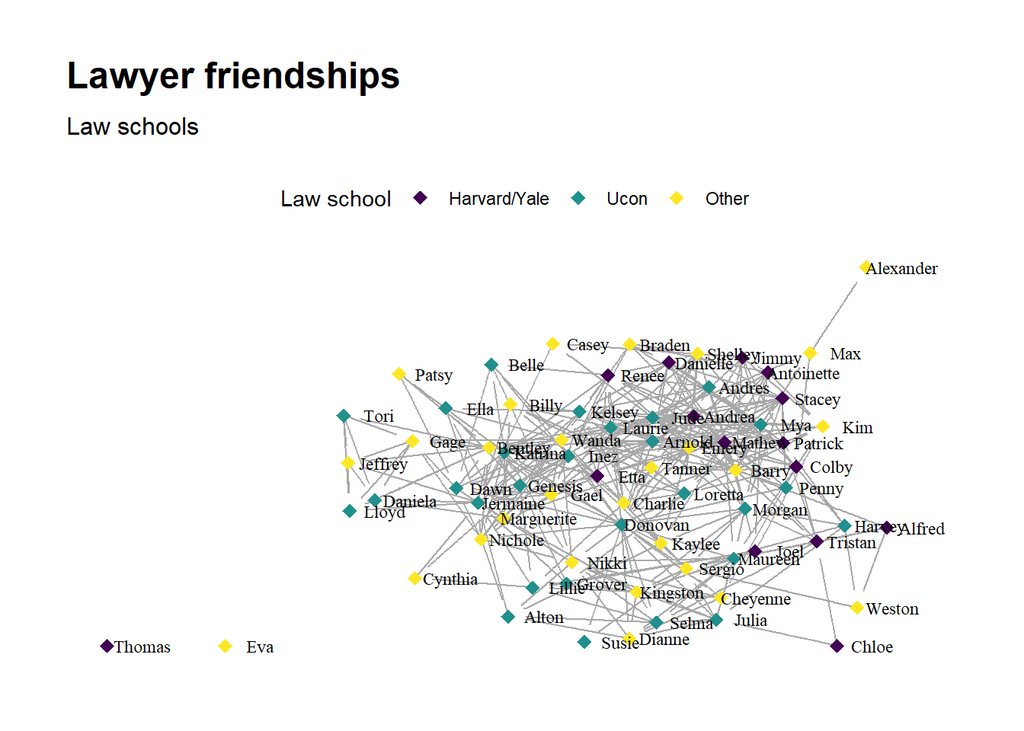

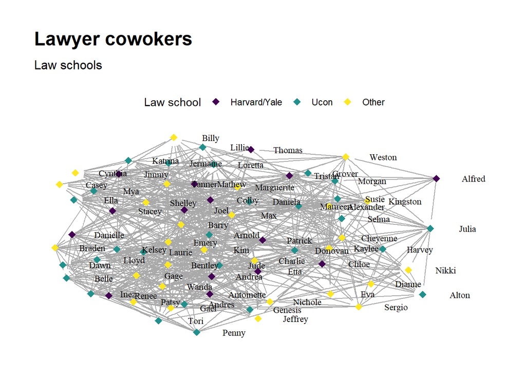

The networks are directed, meaning that ties represent replicated or unreplicated relationships between lawyers without ranking the strength of a relationship or any indication about whether a relationship is positive or negative. For the sake of our project we make them undirected.

# Theory

Rumor and information diffusion is modeled using the different versions of the epidemiological Susceptible-infected (SI) model that originates from the field of public health but has also been frequently used in previous research to analyze not only disease outbreaks but also information diffusion/spread in social networks. [(Woo & Chen, 2016)](https://doi.org/10.1186/s40064-016-1675-x) [(Kumar et al., 2020)](https://doi.org/10.1016/j.procs.2020.04.073).

On the basis of a network that maps the different kinds of connections among lawyers from different universities (advice, friendship, and co-working), we want to illustrate how the spread of rumors among either friends or coworkers can affect the advice information flow between practitioners.

## Part 1: Comparing diffusion among friends and coworkers

We compare the speed of rumor diffusion in friendship and coworking networks (in order to select the network in which the rumor should be spread ideally.) Assuming that gossip spreads faster among friends, as people are willing to talk more openly, transmissibility is set higher (0.25) than among colleagues (0.1). In addition, Harvard/Yale students were excluded from the diffusion simulation as it is unlikely that they would participate in gossip about themselves (assumed immunity to “infection” by the rumor).

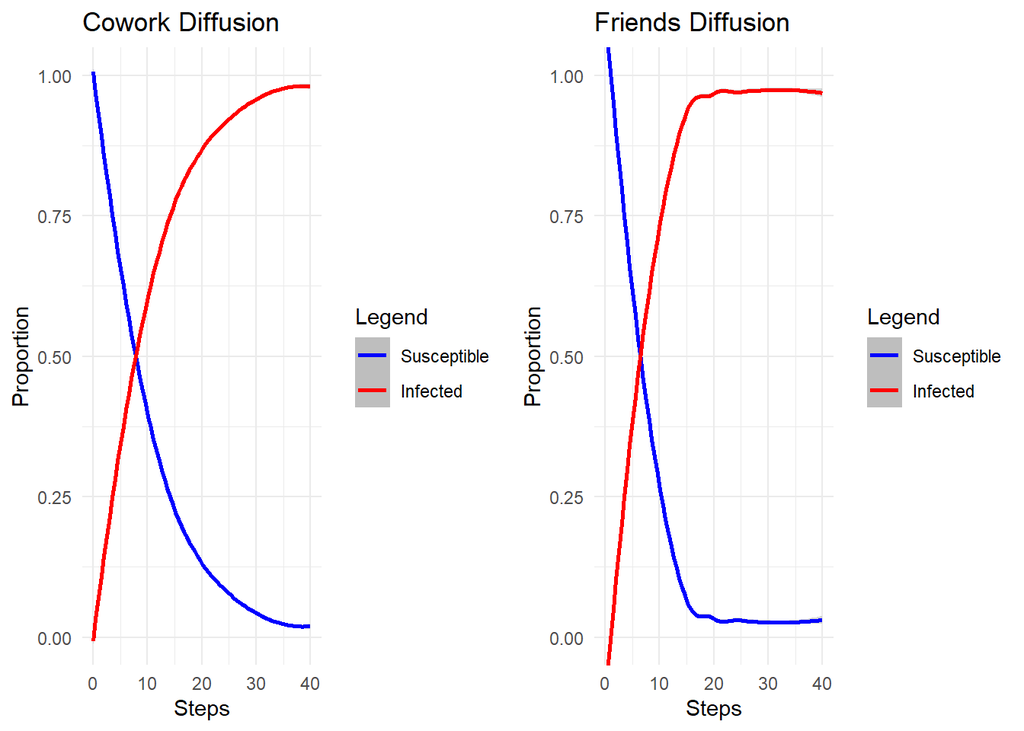

Looking at the plots, in the friendship network, around 10 iterations are required for a rumor to reach 75% of all nodes, while around 15 iterations are required in the cowork network. This is a logical consequence deriving from the assumption about the transmissilbity parameters we have made above.

```
## [1] "Network Transmissibility Cowork"
```

```
## [1] 0.0771
```

```
## [1] "Network Transmissibility Friends"
```

```
## [1] 0.212
```

The faster spread is also confirmed when calculating the transmissibility in individual network diffusion processes. At 0.212, the network transmissibility is much higher in the friends than in the coworkers network at 0.0771.

## Part 2: Comparing diffusion in friends and cowork

We spread the information by using the node with the highest betweenness centrality (not from Harvard/Yale) as the seed node since it indicates that the shortest path to all other nodes leads via this node and in that promotes the flow of information. In reality, not all people will be receptive to rumors and passing them on in the same way. For instance, people over 50 might not be as likely to engage in gossip as younger people as they have experienced many scandals already. We therefore assume that people over 50 need at least 2 people to tell them the rumor in order to accept and pass it on (hence the threshold of 2), and people under 50 only need 1 person. Below is a diagram of the diffusion process that shows the steps of “infection”, i.e. becoming aware of the rumor. It takes 16 time steps (i.e. weeks) until the maximum number of infected nodes (55) is reached.

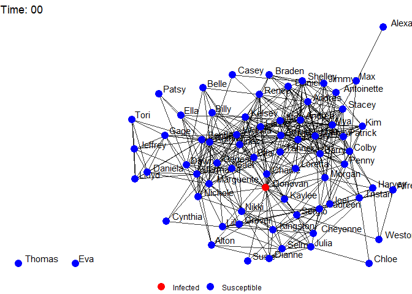

## Part 3: Impact on the Advice Network

Assuming based on distrust due to rumors, people will cut their ties to Harvard/Yale graduates in the advice network. They will no longer be receptive to Harvard professional advice nor pass on information to them. All 55 lawyers who have heard about the rumor in the friendship network after 16 weeks get the attribute “Gossiper”. In a further step, all connections that exist between the graduates of Harvard/Yale and the “Gossipers” are deleted. Since gossip takes some time to spread, to compare we also analyze the information flow after the rumor has spread for only 1 month and 30 are ‘infected’. In the network after the 4 month rumor diffusion, Harvard/Yale graduates are completely cut off from the others, while after one month diffusion, there are still some trust relationships among them and others.

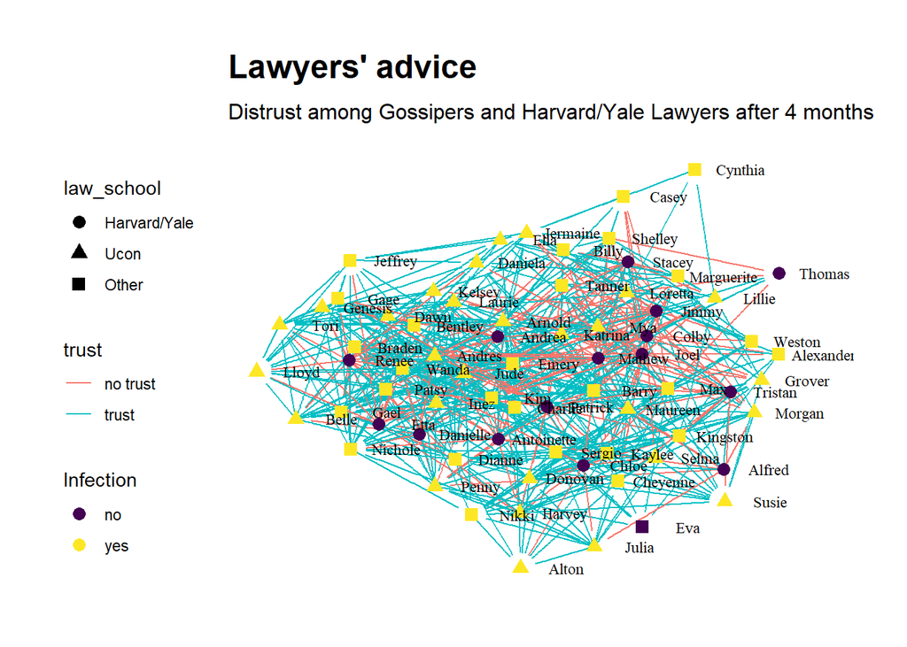

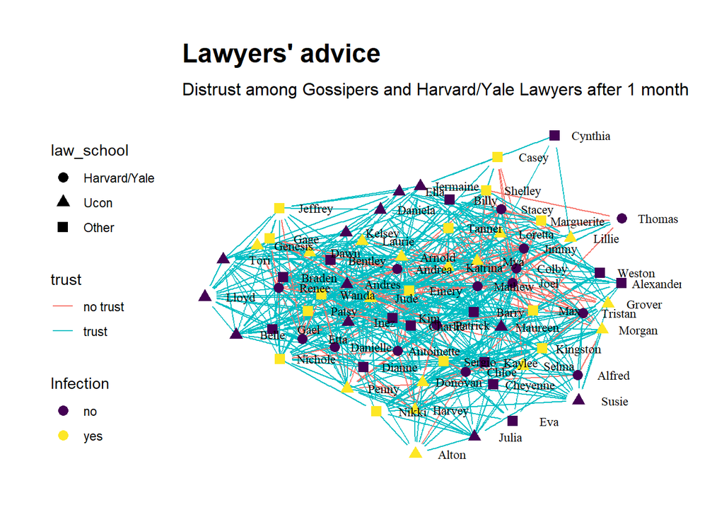

What if Harvard’s most prestigious attorney now proposes a new possible interpretation of case law? Has the rumor negatively impacted the influence that this Harvard attorney has on the practice of law? To this end, we compare the spread of information emanating from the person with the most authority (i.e., the person with the highest eigenvector centrality) in the original legal advice network to the legal advice network affected by the rumor.

We use eigenvector centrality to simulate the most influential lawyer because eigenvector centrality is based on the concept that a node is central if it is connected to other nodes that are themselves central. A reputable Harvard lawyer is most likely connected to many other reputable lawyers, so this concept captures the situation relatively accurately. In our network it is a 50-year old male with 23 years of seniority.

Further, we assume that now more senior people (more than 8 years with the company) need to hear from a higher share of their contacts about the new information to adopt it than less senior people since they are likely to be more experienced and convinced of their own opinion as well as less naive. Law is the “field of interpretability” and concepts are not necessarily hard facts. The information circulating is therefore less convincing/authoritative than in science and we lowered the transmissilbity to 0.25 to account for this.

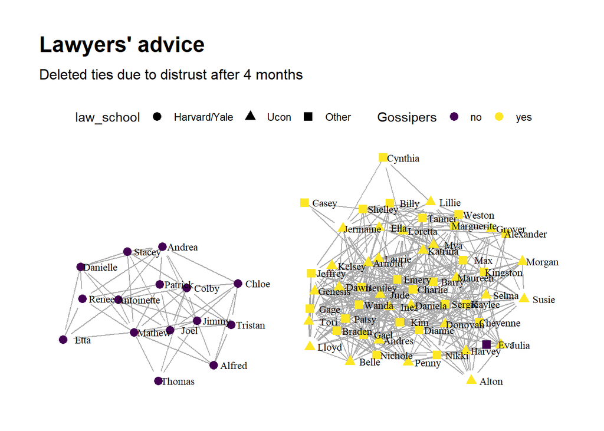

Running one diffusion in the network with 4 months of rumor spread, we can see that the most influential Harvard lawyer can still get to is colleges, yet, the information cannot reach all other practitioners.

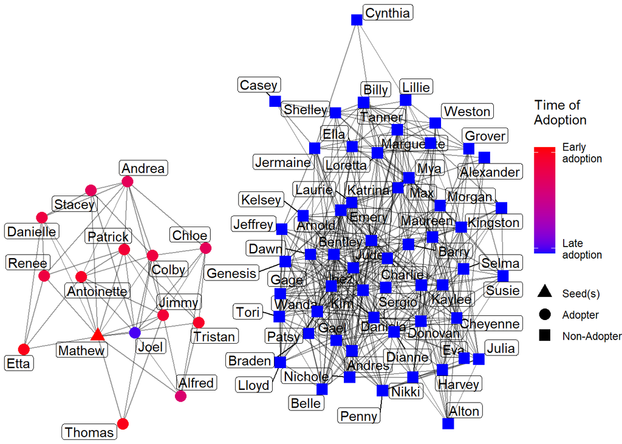

The plots of 100 diffusions show that without distrust due to the spread of the rumor, information flow originating from a prestigious Harvard/Yale lawyer is easiest. After a rumor has been spread for one month, information is already passed on slower due to distrust among attorneys. Lastly, after the gossip has circled for 4 months, Harvard/Yale practitioners can only spread information among themselves.

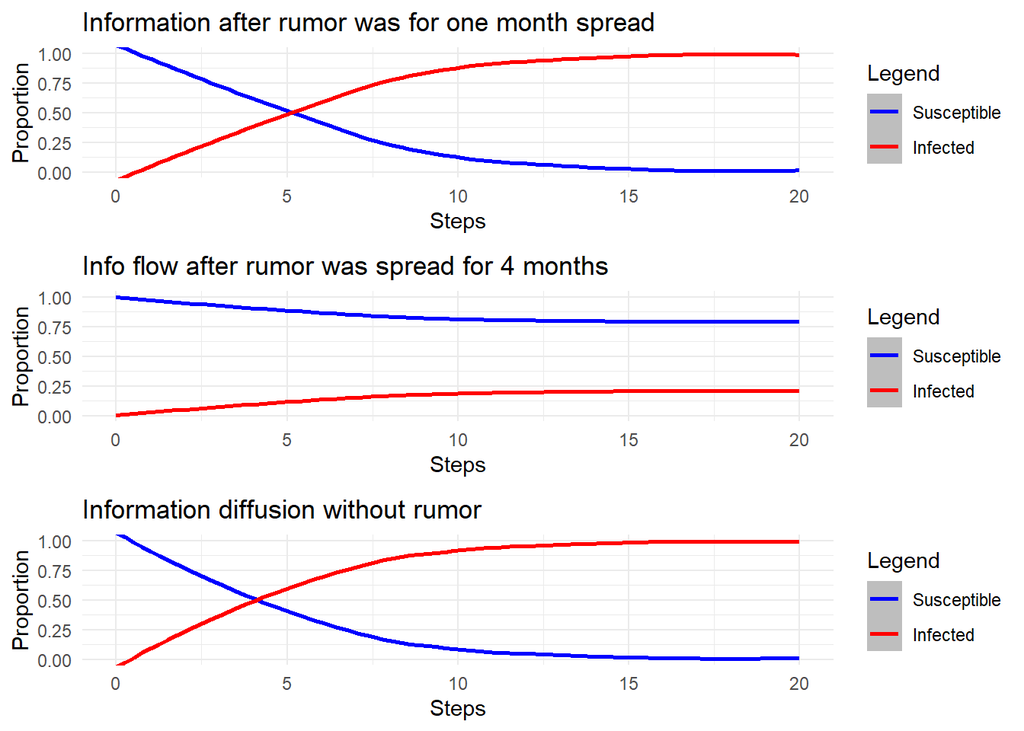

## Conclusion and next Steps

Our analysis shows that Harvard lawyers are indeed not immune (hehe) to scandal. Widespread rumors are enough to undermine their influence and authority, and can even be deliberately instrumentalized to damage the reputation of Harvard lawyers in legal circles.

Further research may analyze how due to rumor information flows less well between gossipers and Harvard/Yale students instead of completely cutting ties between them. Also, a directed network may be considered and investigated at various time points. In addition further refinement of the threshold parameters may be introduced to solidify the analysis. Harvard students therefore might have a higher threshold (i.e. four ppl) to accept a new information since they are very convinced of their current state of knowledge. Furthermore, one could envision to use a SIR model in stead of a simple SI model to refine the simulation. The assumption is that people, are busy, will likely forget the rumor after some time. A recovery parameter could reflect this.

## Bibliography

Kumar, S., Saini, M., Goel, M., & Aggarwal, N. (2020). Modeling Information Diffusion In Online Social Networks Using SEI Epidemic Model. Procedia Computer Science, 171, 672–678. https://doi.org/10.1016/j.procs.2020.04.073 Nesterak, E. (2023, July 5). Harvard Professor Under Scrutiny for Alleged Data Fraud - By Evan Nesterak. Behavioral Scientist. https://behavioralscientist.org/harvard-professor-under-scrutiny-for-alleged-data-fraud/ Raub, W. (2005). Emmanuel Lazega: The Collegial Phenomenon. The Social Mechanisms of Cooperation among Peers in a Corporate Law Partnership. Oxford: Oxford University Press, 2001. xi + 346 pp. European Sociological Review, 21(2), 183–184. https://doi.org/10.1093/esr/jci012 Woo, J., & Chen, H. (2016). Epidemic model for information diffusion in web forums: experiments in marketing exchange and political dialog. SpringerPlus, 5(1). https://doi.org/10.1186/s40064-016-1675-x